# HW8 - KELLY “SCOTT” SIMS

Using the crime data set uscrime.txt from Questions 8.2, 9.1, and 10.1, build a regression model using: 1. Stepwise regression 2. Lasso 3. Elastic net For Parts 2 and 3, remember to scale the data first – otherwise, the regression coefficients will be on different scales and the constraint won’t have the desired effect. For Parts 2 and 3, use the glmnet function in R. Notes on R: • For the elastic net model, what we called lambda in the videos, glmnet calls “alpha”; you can get a range of results by varying alpha from 1 (lasso) to 0 (ridge regression) [and, of course, other values of alpha in between]. • In a function call like glmnet(x,y,family=”mgaussian”,alpha=1) the predictors x need to be in R’s matrix format, rather than data frame format. You can convert a data frame to a matrix using as.matrix – for example, x <- as.matrix(data[,1:n-1]) • Rather than specifying a value of T, glmnet returns models for a variety of values of T.

```r
library(olsrr)
```

```r
data <- read.table('uscrime.txt', header = TRUE, stringsAsFactors = FALSE)
head(data)
```

|  | M | So | Ed | Po1 | Po2 | LF | M.F | Pop | NW | U1 | U2 | Wealth | Ineq | Prob | Time | Crime |
| --- | --- | --- | --- | --- | --- | --- | --- | --- | --- | --- | --- | --- | --- | --- | --- | --- |
| 1 | 15.1 | 1 | 9.1 | 5.8 | 5.6 | 0.510 | 95.0 | 33 | 30.1 | 0.108 | 4.1 | 3940 | 26.1 | 0.084602 | 26.2011 | 791 |
| 2 | 14.3 | 0 | 11.3 | 10.3 | 9.5 | 0.583 | 101.2 | 13 | 10.2 | 0.096 | 3.6 | 5570 | 19.4 | 0.029599 | 25.2999 | 1635 |
| 3 | 14.2 | 1 | 8.9 | 4.5 | 4.4 | 0.533 | 96.9 | 18 | 21.9 | 0.094 | 3.3 | 3180 | 25.0 | 0.083401 | 24.3006 | 578 |
| 4 | 13.6 | 0 | 12.1 | 14.9 | 14.1 | 0.577 | 99.4 | 157 | 8.0 | 0.102 | 3.9 | 6730 | 16.7 | 0.015801 | 29.9012 | 1969 |
| 5 | 14.1 | 0 | 12.1 | 10.9 | 10.1 | 0.591 | 98.5 | 18 | 3.0 | 0.091 | 2.0 | 5780 | 17.4 | 0.041399 | 21.2998 | 1234 |
| 6 | 12.1 | 0 | 11.0 | 11.8 | 11.5 | 0.547 | 96.4 | 25 | 4.4 | 0.084 | 2.9 | 6890 | 12.6 | 0.034201 | 20.9995 | 682 |

# STEPWISE REGRESSION

For stepweise regression, thankfully R already has a module that will handle the very iterative process of adding and subtracting features while training the model and analyzing it. Let’s put that funciton to use and build regression models using **Stepwise Regression**. The *ols_step_both_p* function selects features based on p-value. Because of this, we can set the upper and lower bounds of the p-value for the function to take into consideration when it is selecting its features. We will set the “pent” equal to 0.1, meaning variables with p value less than 0.1 will enter into the model. Will will set “prem” equal to 0.3 meaning variables with p value more than 0.3 will not enter into the model

```r
stepwise.model <- lm(Crime ~., data = data)
step <- ols_step_both_p(stepwise.model, pent = 0.1, prem = 0.3, details = TRUE)
```

```
Stepwise Selection Method
---------------------------

Candidate Terms:

1. M
2. So
3. Ed
4. Po1
5. Po2
6. LF
7. M.F
8. Pop
9. NW
10. U1
11. U2
12. Wealth
13. Ineq
14. Prob
15. Time

We are selecting variables based on p value...


Stepwise Selection: Step 1

✔ Po1

                          Model Summary
-----------------------------------------------------------------
R                       0.688       RMSE                 283.926
R-Squared               0.473       Coef. Var             31.370
Adj. R-Squared          0.461       MSE                80613.907
Pred R-Squared          0.393       MAE                  218.298
-----------------------------------------------------------------
 RMSE: Root Mean Square Error
 MSE: Mean Square Error
 MAE: Mean Absolute Error

                                 ANOVA
```

[output cut: 393 more lines]

```
Total         6880927.660        46
-----------------------------------------------------------------------

                                       Parameter Estimates
-------------------------------------------------------------------------------------------------
      model         Beta    Std. Error    Std. Beta      t        Sig         lower        upper
-------------------------------------------------------------------------------------------------
(Intercept)    -5040.505       899.843                 -5.602    0.000    -6859.156    -3221.854
        Po1      115.024        13.754        0.884     8.363    0.000       87.227      142.821
       Ineq       67.653        13.936        0.698     4.855    0.000       39.488       95.818
         Ed      196.471        44.754        0.568     4.390    0.000      106.019      286.923
          M      105.020        33.299        0.341     3.154    0.003       37.719      172.320
       Prob    -3801.836      1528.097       -0.224    -2.488    0.017    -6890.236     -713.436
         U2       89.366        40.906        0.195     2.185    0.035        6.693      172.039
-------------------------------------------------------------------------------------------------
```

```r
step
```

```
                              Stepwise Selection Summary
---------------------------------------------------------------------------------------
                     Added/                   Adj.
Step    Variable    Removed     R-Square    R-Square     C(p)        AIC         RMSE
---------------------------------------------------------------------------------------
   1      Po1       addition       0.473       0.461    39.9970    668.3155    283.9259
   2      Ineq      addition       0.580       0.561    25.0710    659.5957    256.1874
   3       Ed       addition       0.666       0.642    13.6390    650.9145    231.3136
   4       M        addition       0.700       0.672    10.1620    647.7503    221.5397
   5      Prob      addition       0.738       0.706     6.2580    643.4641    209.7205
   6       U2       addition       0.766       0.731     3.8600    640.1661    200.6899
---------------------------------------------------------------------------------------
```

**Analysis** We can see above that each step is a concatenation of the previous model, starting at Po1*, and the next feature. We can see at the bottom of the iterations, we ended up with a model that had 15 candidates for features but now is constructed by only 6 of them. The stepwise selection summary shows that with each feature addition, RMSE, AIC, and C(p) were dropping, while R-squared and Adjusted R-squared are increasing. This is the effect we like to see. We can plot the model to illustrate how much these metrics changed with each addition of a new feature.

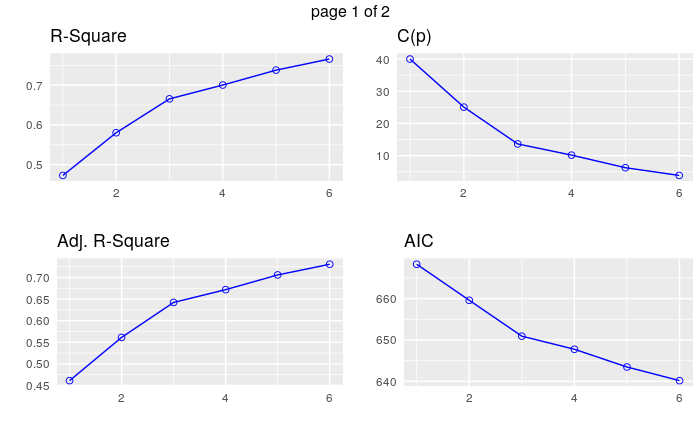

```r
plot(step)
```

```r
#Unseen data given a previous HW assignment
new.data <- data.frame("M"= 14,
"So" = 0,
"Ed" = 10,
"Po1" = 12,
"Po2" = 15.5,
"LF" = .640,
"M.F" = 94,
"Pop" = 150,
"NW" = 1.1,
"U1" = .120,
"U2" = 3.6,
"Wealth" = 3200,
"Ineq" = 20.1,
"Prob" = .04,
"Time" = 39)
```

Let’s use the best model from Stepwise Regression to predict on the unseen data that was presented in Week 5 for the Crime data. Predictions on previous models were in the range of 1100 to 1350. So we should expect to see a prediction from this model within that range.

```r
best_step.model <- step$model
unseen_step <- new.data[,c('Po1', 'Ineq', 'Ed','M','Prob','U2')]
predict(best_step.model, unseen_step)
```

```
       1
1304.245
```

The prediction is well within the expected range of Crime predictions.

# LASSO REGRESSION

Next, we will implement LASSO Regression, which can consequently drive feature coeffecicents to zero with a high enough hyperparameter of alpha (lambda). Let’s see what features LASSO selects vs Stepwise

```r
require(glmnet)
require(caret)
```

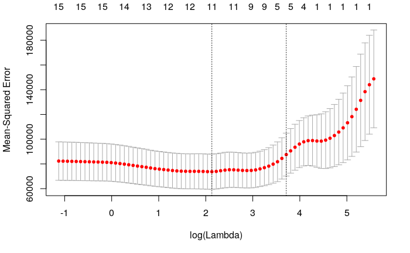

```r
set.seed(42)
#Scale the train data
x <- as.data.frame(data[,1:15])
pp = preProcess(x)
scaled_x <- as.matrix(predict(pp, x))
#Scale the test data
scaled_test <- as.matrix(predict(pp, new.data))
#target variable
y <- data[,16]
lasso <- cv.glmnet(scaled_x,y, family = 'gaussian', alpha = 1, parallel = TRUE)
plot(lasso)
```

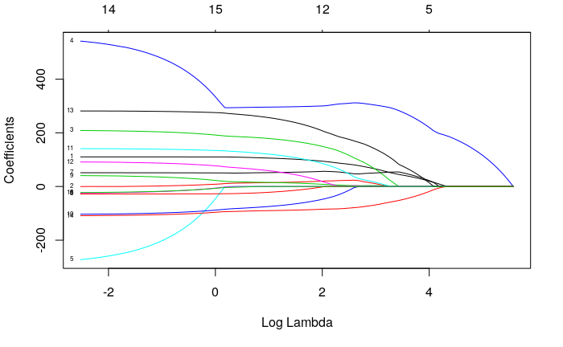

```r
plot(lasso$glmnet.fit, xvar='lambda', label = TRUE)
```

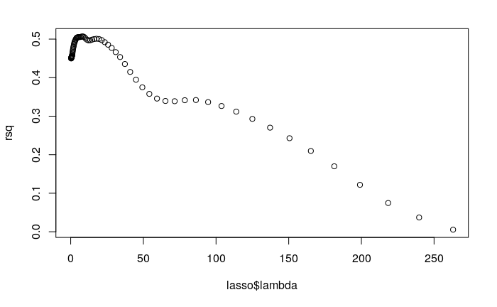

```r
rsq = 1 - lasso$cvm/var(y)
plot(lasso$lambda,rsq)
```

```r
coeffecients <- coef(lasso, s=lasso$lambda.min)
coeffecients
```

```
16 x 1 sparse Matrix of class "dgCMatrix"
                     1
(Intercept) 905.085106
M            91.605916
So           20.875623
Ed          143.159609
Po1         302.645106
Po2           .
LF            .
M.F          55.995942
Pop           .
NW            7.047715
U1          -41.517302
U2           78.040254
Wealth       10.762412
Ineq        198.440786
Prob        -83.952696
Time          .
```

```r
paste('Minimum MSE: ',min(lasso$cvm))
```

```
[1] "Minimum MSE:  73725.9799218528"
```

```r
paste('Maximum R^2: ', max(rsq))
```

```
[1] "Maximum R^2:  0.507131124727598"
```

```r
coeffecients[1] + coeffecients[2]*scaled_test[1] + coeffecients[3]*scaled_test[2] + coeffecients[4]*scaled_test[3] + coeffecients[5]*scaled_test[4] + coeffecients[6]*scaled_test[5] + coeffecients[7]*scaled_test[6] + coeffecients[8]*scaled_test[7] + coeffecients[9]*scaled_test[8] + coeffecients[10]*scaled_test[9] + coeffecients[11]*scaled_test[10] + coeffecients[12]*scaled_test[11] + coeffecients[13]* scaled_test[12] + coeffecients[14]*scaled_test[13] + coeffecients[15]*scaled_test[14] + coeffecients[16]*scaled_test[15]
```

```
[1] 1097.259
```

# Elastic Net

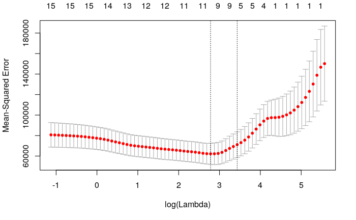

```r
set.seed(24)
elastic <- cv.glmnet(x = scaled_x, y = y, family = 'gaussian')
plot(elastic)
```

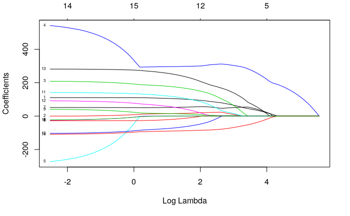

```r
plot(elastic$glmnet.fit, xvar='lambda', label = TRUE)
```

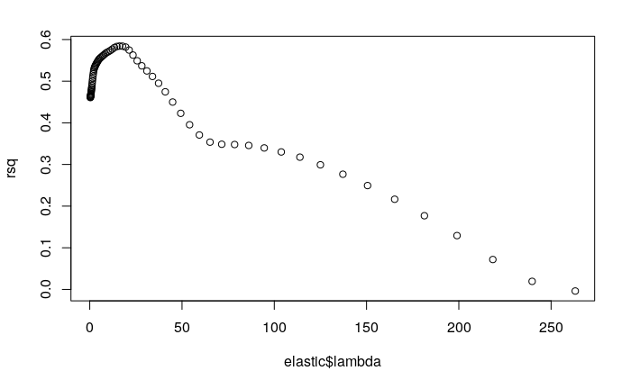

```r
coeffecients <- coef(elastic, s = 'lambda.min')
rsq = 1 - elastic$cvm/var(y)
plot(elastic$lambda,rsq)
```

```r
coeffecients
```

```
16 x 1 sparse Matrix of class "dgCMatrix"
                      1
(Intercept) 905.0851064
M            74.0174295
So           17.7133651
Ed           89.5805899
Po1         309.1881837
Po2           .
LF            0.4790569
M.F          48.4916943
Pop           .
NW            3.2640901
U1            .
U2           24.9595863
Wealth        .
Ineq        158.3327124
Prob        -74.8230648
Time          .
```

```r
paste('Minimum MSE: ',min(elastic$cvm))
```

```
[1] "Minimum MSE:  62201.8759075783"
```

```r
paste('Maximum R^2: ', max(rsq))
```

```
[1] "Maximum R^2:  0.584171432500491"
```

```r
coeffecients[1] + coeffecients[2]*scaled_test[1] + coeffecients[3]*scaled_test[2] + coeffecients[4]*scaled_test[3] + coeffecients[5]*scaled_test[4] + coeffecients[6]*scaled_test[5] + coeffecients[7]*scaled_test[6] + coeffecients[8]*scaled_test[7] + coeffecients[9]*scaled_test[8] + coeffecients[10]*scaled_test[9] + coeffecients[11]*scaled_test[10] + coeffecients[12]*scaled_test[11] + coeffecients[13]* scaled_test[12] + coeffecients[14]*scaled_test[13] + coeffecients[15]*scaled_test[14] + coeffecients[16]*scaled_test[15]
```

```
[1] 1204.24
```